# Analyzing NYPD Shooting Incidents

Punam Paul

2023-08-20

## NYPD Shooting Incident Data (Historic)

Load the CSV data from *url* into *nypd_data* variable.

```r
url <- "https://data.cityofnewyork.us/api/views/833y-fsy8/rows.csv"
nypd_data <- read_csv(url)
```

## Tidying and Transforming the Data

Tidy up the data. Remove x-y coordinates, latitude/longitude and convert *OCCUR_DATE* from *chr* to *date* datatype.

```r
nypd_data <- nypd_data %>% select(-(X_COORD_CD:Lon_Lat)) %>% mutate(OCCUR_DATE = mdy(OCCUR_DATE))
```

## Analyzing Shooting Incidents by Borough Over the Years

Extract *OCCUR_YEAR* from *OCCUR_DATE*, calculate counts of shooting incidents for each borough and year.

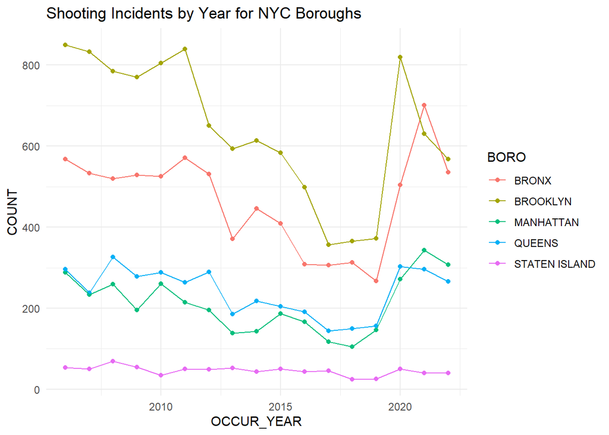

```r
nypd_data_by_boro <- nypd_data %>% mutate(OCCUR_YEAR=year(OCCUR_DATE)) %>% group_by(BORO, OCCUR_YEAR) %>% summarize(COUNT=n())

ggplot(nypd_data_by_boro, aes(x=OCCUR_YEAR, y=COUNT, colour=BORO)) + geom_point() + geom_line() + theme_minimal() + ggtitle("Shooting Incidents by Year for NYC Boroughs")
```

## Visualizing Murders for Every Borough Over the Years

Extract *OCCUR_YEAR* from *OCCUR_DATE*. Then we filter incidents where *STATISTICAL_MURDER_FLAG* is set to *TRUE*. Then calculate counts of murders for each borough and year.

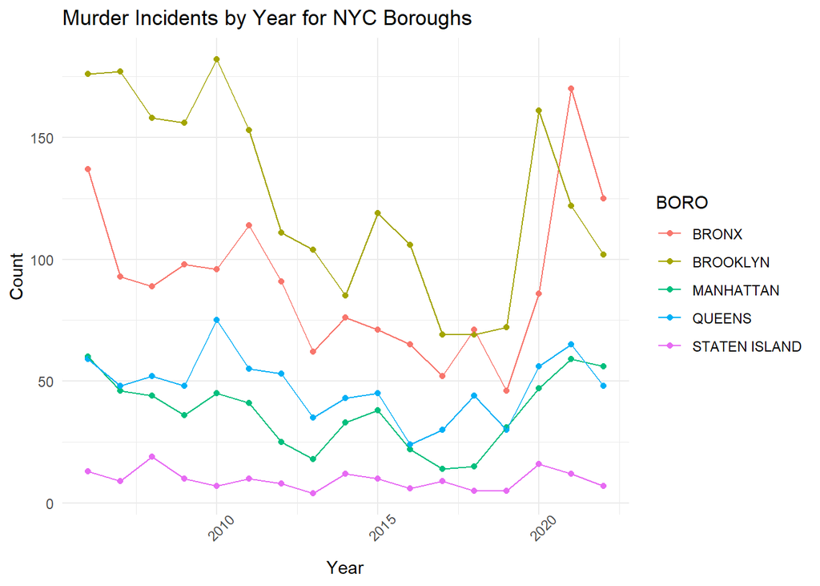

```r
nypd_data_by_boro_murders <- nypd_data %>% filter(STATISTICAL_MURDER_FLAG) %>% mutate(OCCUR_YEAR=year(OCCUR_DATE)) %>% group_by(BORO, OCCUR_YEAR) %>% summarize(COUNT=n())

ggplot(nypd_data_by_boro_murders, aes(x=OCCUR_YEAR, y=COUNT, colour=BORO)) + geom_point() + geom_line() + theme_minimal() + ggtitle("Murder Incidents by Year for NYC Boroughs") + theme(axis.text.x = element_text(angle = 45)) + labs(x="Year", y="Count")
```

## Visualizing Shooting Incidents by Location (Inside/Outside)

Drop NA values for *LOC_OF_OCCUR_DESC* column. Then do a bar chart on *LOC_OF_OCCUR_DESC* column.

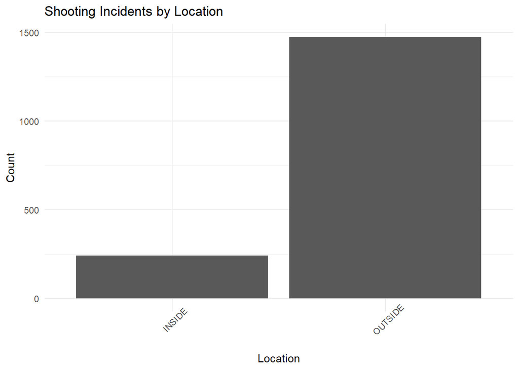

```r
nypd_data_by_location <- nypd_data %>% drop_na(LOC_OF_OCCUR_DESC)

ggplot(nypd_data_by_location, aes(LOC_OF_OCCUR_DESC)) + geom_bar() + theme_minimal() + ggtitle("Shooting Incidents by Location") + theme(axis.text.x = element_text(angle = 45)) + labs(x="Location", y="Count")
```

## Visualizing Shooting Incidents by Victim Age Group

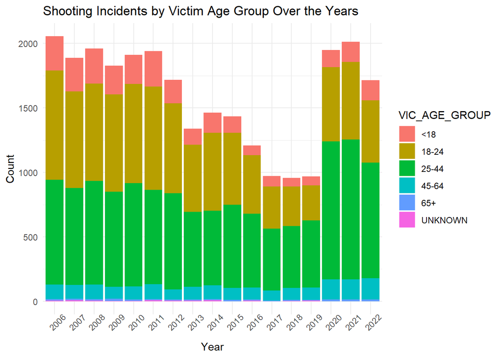

```r
nypd_data_by_vic <- nypd_data %>% drop_na(VIC_AGE_GROUP) %>% filter(VIC_AGE_GROUP != 1022) %>% mutate(OCCUR_YEAR=year(OCCUR_DATE))

ggplot(nypd_data_by_vic, aes(x=as.factor(OCCUR_YEAR), fill=VIC_AGE_GROUP)) + geom_bar() + theme_minimal() + ggtitle("Shooting Incidents by Victim Age Group Over the Years") + theme(axis.text.x = element_text(angle = 45)) + labs(x="Year", y="Count")
```

## Visualizing Shooting Incidents by Perp Age Group

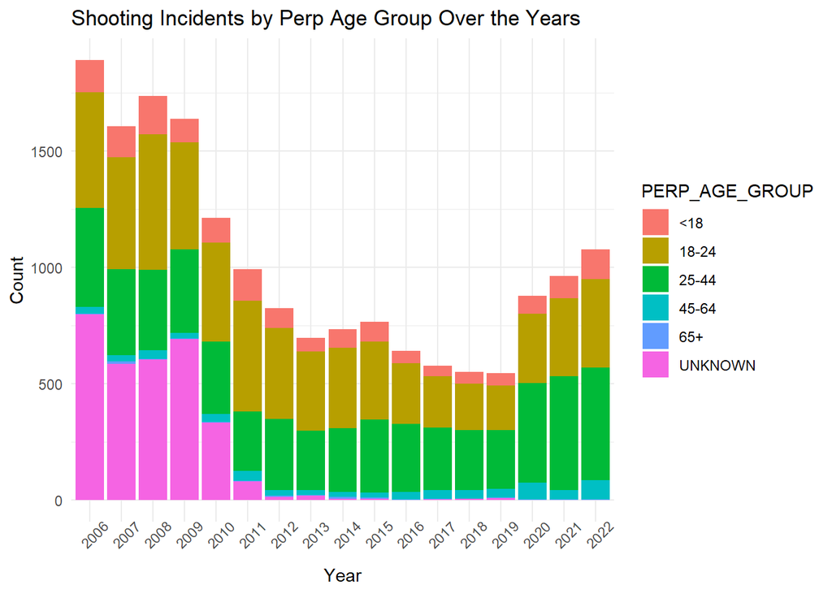

```r
nypd_data_by_perp <- nypd_data %>% drop_na(PERP_AGE_GROUP) %>% filter(PERP_AGE_GROUP != 1020 & PERP_AGE_GROUP != 224 & PERP_AGE_GROUP != 940 & PERP_AGE_GROUP != "(null)") %>% mutate(OCCUR_YEAR=year(OCCUR_DATE))

ggplot(nypd_data_by_perp, aes(x=as.factor(OCCUR_YEAR), fill=PERP_AGE_GROUP)) + geom_bar() + theme_minimal() + ggtitle("Shooting Incidents by Perp Age Group Over the Years") + theme(axis.text.x = element_text(angle = 45)) + labs(x="Year", y="Count")
```

## Visualizing Sex of Victims

Drop NA values and plot a bar chart over the years.

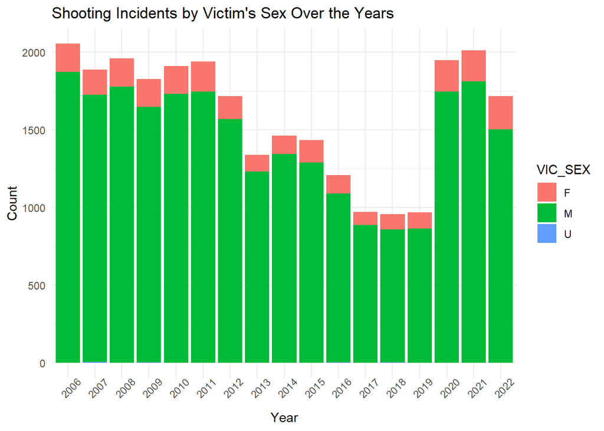

```r
nypd_data_by_vic_sex <- nypd_data %>% drop_na(VIC_SEX) %>% mutate(OCCUR_YEAR=year(OCCUR_DATE))

ggplot(nypd_data_by_vic_sex, aes(x=as.factor(OCCUR_YEAR), fill=VIC_SEX)) + geom_bar() + theme_minimal() + ggtitle("Shooting Incidents by Victim's Sex Over the Years") + theme(axis.text.x = element_text(angle = 45)) + labs(x="Year", y="Count")
```

## Visualizing Sex of Perp

Drop NA values and plot a bar chart over the years.

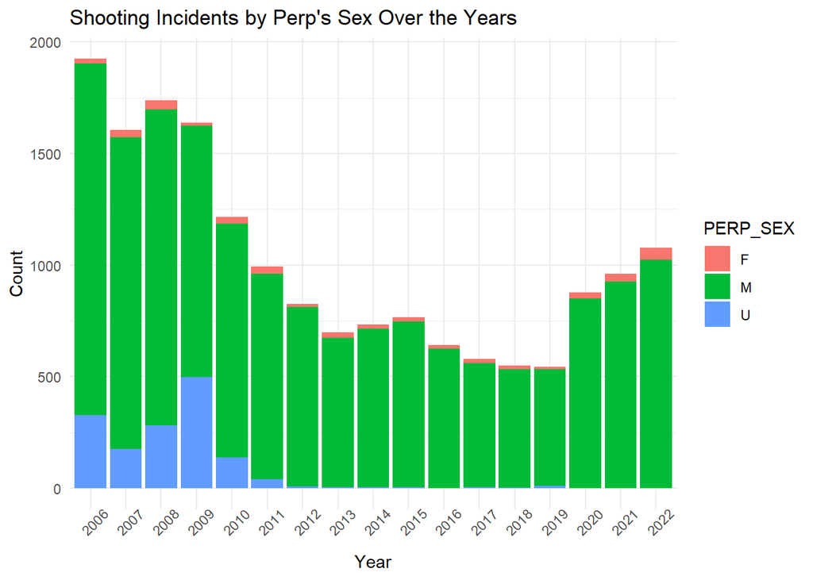

```r
nypd_data_by_perp_sex <- nypd_data %>% drop_na(PERP_SEX) %>% mutate(OCCUR_YEAR=year(OCCUR_DATE)) %>% filter(PERP_SEX != "(null)")

ggplot(nypd_data_by_perp_sex, aes(x=as.factor(OCCUR_YEAR), fill=PERP_SEX)) + geom_bar() + theme_minimal() + ggtitle("Shooting Incidents by Perp's Sex Over the Years") + theme(axis.text.x = element_text(angle = 45)) + labs(x="Year", y="Count")
```

## Visualizing Time of Shooting

Drop NA values from *OCCUR_TIME* column, extract the hour value and then plot a line chart.

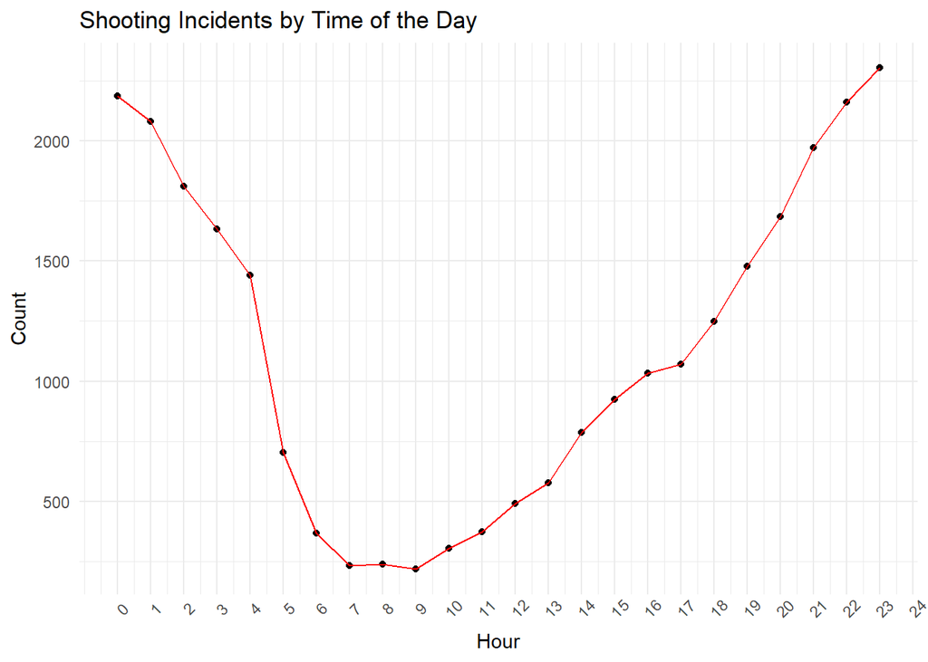

```r
nypd_data_by_time <- nypd_data %>% drop_na(OCCUR_TIME) %>% mutate(OCCUR_HOUR=hour(OCCUR_TIME)) %>% group_by(OCCUR_HOUR) %>% summarize(COUNT=n())

ggplot(nypd_data_by_time, aes(OCCUR_HOUR, COUNT)) + geom_point() + geom_line(colour="RED") + theme_minimal() + ggtitle("Shooting Incidents by Time of the Day") + scale_x_continuous(breaks = round(seq(0, 24, by = 1),1)) + theme(axis.text.x = element_text(angle = 45)) + labs(x="Hour", y="Count")
```

## Data Modeling: Predict Sex of the Victim Based on the Sex of the Perp

We are modeling the data using decision tree with *rpart* library. We are predicting *VIC_SEX* based on *PERP_SEX* and *VIC_AGE_GROUP* features. First, we will remove unknown and NA values from *PERP_SEX* and *VIC_SEX* columns, and drop NA values from *VIC_AGE_GROUP* column. Then we do a test-train split and create a decision tree. We predict the *VIC_SEX_PREDICTED* column for *nypd_test* dataset.

```r
nypd_data_sex <- nypd_data %>% drop_na(VIC_SEX) %>% drop_na(PERP_SEX) %>% drop_na(VIC_AGE_GROUP) %>% filter(VIC_SEX == 'M' | VIC_SEX == 'F') %>% filter(PERP_SEX == 'M' | PERP_SEX == 'F')

set.seed(4650)
train_index <- createDataPartition(nypd_data_sex$VIC_SEX,
                                  p = .80,
                                  list = FALSE,
                                  times = 1)

nypd_train <- nypd_data_sex[ train_index,]
nypd_test  <- nypd_data_sex[-train_index,]

mytree <- rpart(
  VIC_SEX ~ PERP_SEX + VIC_AGE_GROUP,
  data = nypd_train,
  method="class"
  )


nypd_test$VIC_SEX_PREDICTED <- predict(mytree, newdata = nypd_test, type = "class")
```

## Model Bias

Based on the histogram, we can see that the model predicted all victims to be of male sex. We can see in the second histogram that in the *nypd_train* dataset, over 80% of the victims are of male sex. The decision tree model showed bias while predicting the *VIC_SEX* to show all the victims as men. We can either use more complex models or do model tuning to reduce the model bias.

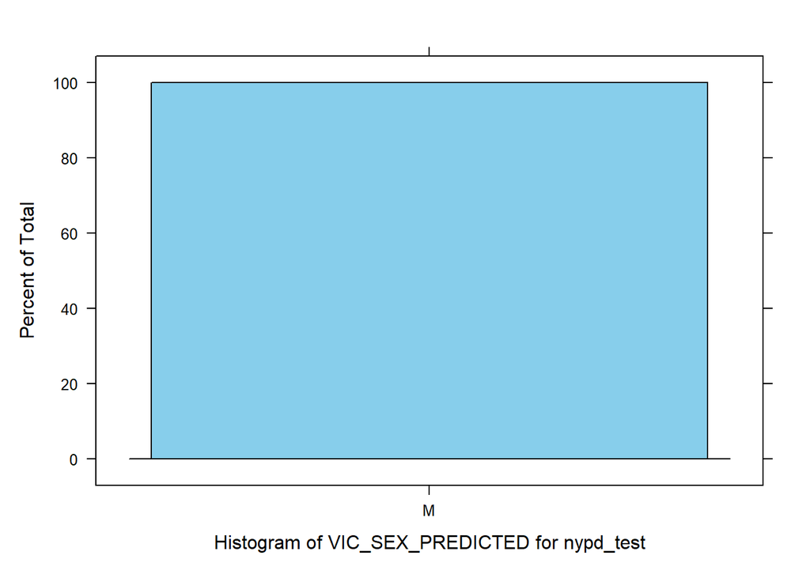

```r
histogram(as.factor(nypd_test$VIC_SEX_PREDICTED), col=c("skyblue"), xlab="Histogram of VIC_SEX_PREDICTED for nypd_test")
```

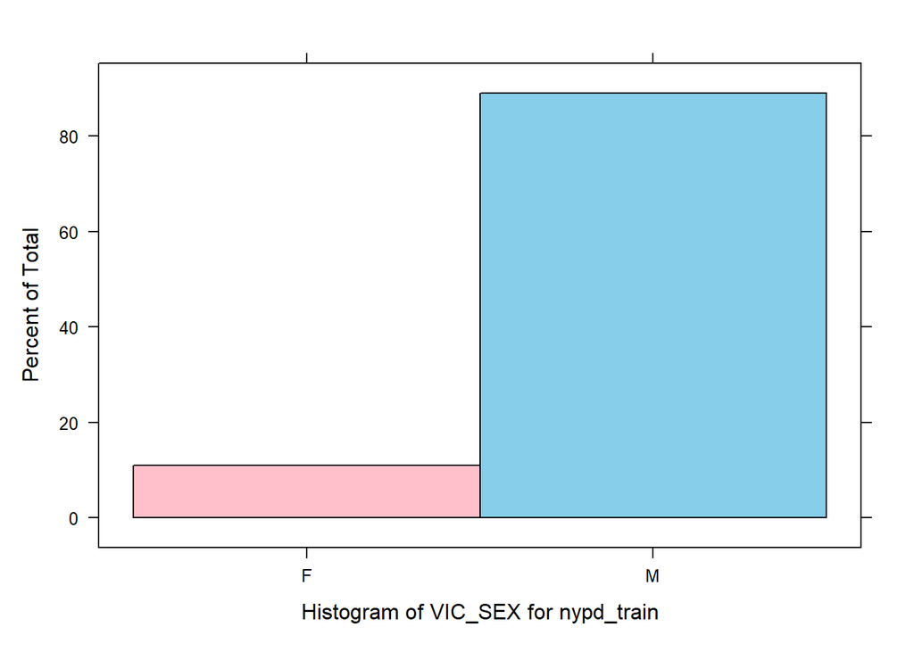

```r
histogram(as.factor(nypd_train$VIC_SEX), col=c("pink", "skyblue"), xlab="Histogram of VIC_SEX for nypd_train")
```